# Clustering Swiss Cities

## Background

You are searching for a perfect city to start your new business, or simply you believe moving to another location would do good to your current company, as the grass looks greener on the other side of the fence? Either way, the choice is not an easy task! Whether you open a new restaurant, a hotel or a bar, you need to know the existing market in the potential city of your choice. It would be beneficial to know what people are like, what kind of activities they prefer, and places they go to. There are many parameters to consider, but the location should be among the most important ones. You may feel that by being in close proximity to your competitors, you can benefit from their marketing efforts. They spent a considerable amount of resources to find their location and drive traffic to it. Alternatively, you would prefer a place with not as many similar businesses, in order to set the brand. One or the other, location data is an important asset in such decision-making processes. Putting efforts into making a good use of it could be beneficial for anyone considering starting a new business or moving it to another location.

This notebook will explore [Foursquare](http://www.foursquare.com) data of venues in the 10 biggest cities of Switzerland:

1. **Zurich**
2. **Geneva**
3. **Basel**
4. **Lausanne**
5. **Bern**
6. **Winterthur**
7. **Lucerne**
8. **St. Gallen**
9. **Lugano**
10. **Biel/Bienne**

Using the forusquare API, the cities will be explored by searching venues around each of the ZIP code's latitude and longitude points. For each ZIP code, a maximum of 200 venues will be pulled out within the radius of **1km** (duplicates removed). Venue categories will be extracted from each place, and k-means clustering algorithm will be used to find patterns and cluster similar city areas.

## Libraries

Apart from the typical libraries such as **numpy** and **pandas** for data handling, **matplotlib** and **seaborn** for visualization, **requests** is used for HTTP GET requests, **folium** for geospatial data representation, **geocoder** for obtaining the latitude and longitude information, and **sklearn** for modeling.

```python
import pandas as pd
import numpy as np
import matplotlib.pyplot as plt
import seaborn as sns
%matplotlib inline

import requests
import geocoder
import folium
from pandas.io.json import json_normalize
from sklearn.cluster import KMeans

import matplotlib.cm as cm
import matplotlib.colors as colors
```

## Data sources

First of all, a file containing the zip codes of the whole Switzerland is imported. The file is obtained from the location data resource AggData. For the rest of the data, a Foursquare API was used in later parts of the notebook to get the information about the venus, using the imported zip codes.

```python
!wget -q -O 'temp.zip' https://www.aggdata.com/system/files_force/samples/ch_postal_codes.zip; unzip temp.zip; rm temp.zip
```

## Data exploration

```python
ch_postal_codes = pd.read_csv('Data/ch_postal_codes.csv', encoding="latin1")
ch_postal_codes.head(5)
```

|  | Postal Code | Place Name | State | State Abbreviation | County | City | Latitude | Longitude |
| --- | --- | --- | --- | --- | --- | --- | --- | --- |
| 0 | 5000.0 | Aarau | Kanton Aargau | AG | Bezirk Aarau | Aarau | 47.3890 | 8.0487 |
| 1 | 5001.0 | Aarau | Kanton Aargau | AG | Bezirk Aarau | Aarau | 47.3922 | 8.0497 |
| 2 | 5004.0 | Aarau | Kanton Aargau | AG | Bezirk Aarau | Aarau | 47.4005 | 8.0606 |
| 3 | 5017.0 | Barmelweid | Kanton Aargau | AG | Bezirk Aarau | Erlinsbach (AG) | 47.4216 | 7.9700 |
| 4 | 5018.0 | Erlinsbach | Kanton Aargau | AG | Bezirk Aarau | Erlinsbach (AG) | 47.4126 | 8.0089 |

```python
ch_postal_codes.drop(['Place Name', 'County', 'State Abbreviation', 'State'], axis=1, inplace=True)
ch_postal_codes.dropna(inplace=True)
ch_postal_codes['Postal Code'] = ch_postal_codes['Postal Code'].astype(int)
ch_postal_codes.head(5)
```

|  | Postal Code | City | Latitude | Longitude |
| --- | --- | --- | --- | --- |
| 0 | 5000 | Aarau | 47.3890 | 8.0487 |
| 1 | 5001 | Aarau | 47.3922 | 8.0497 |
| 2 | 5004 | Aarau | 47.4005 | 8.0606 |
| 3 | 5017 | Erlinsbach (AG) | 47.4216 | 7.9700 |
| 4 | 5018 | Erlinsbach (AG) | 47.4126 | 8.0089 |

### Map of all zipcode points for the 10 biggest cities

First of all, let's separate the zip codes of only the selected cities

```python
ch_big10_cities = ['Z\xfcrich', 'Gen\xE8ve', 'Basel', 'Lausanne', 'Bern', 'Winterthur', 'Luzern', 'St. Gallen', 'Lugano', 'Biel/Bienne']
ch_cities = ch_postal_codes[ch_postal_codes['City'].isin(ch_big10_cities)].copy()
ch_cities.reset_index(inplace=True, drop=True)
```

```python
lat_lng_coords = None
while(lat_lng_coords is None):
    g = geocoder.google('Switzerland')
    lat_lng_coords = g.latlng

map_ch = folium.Map(location=[lat_lng_coords[0], lat_lng_coords[1]], zoom_start=8)
for lat, lng, city in zip(ch_cities['Latitude'], ch_cities['Longitude'], ch_cities['City']):
    label = '{}'.format(city)
    label = folium.Popup(label, parse_html=True)
    folium.CircleMarker(
        [lat, lng],
        radius=5,
        popup=label,
        color='blue',
        fill=True,
        fill_color='#3186cc',
        fill_opacity=0.7).add_to(map_ch)

map_ch
```

[interactive chart not shown]

```python
ch_cities.loc[:, "City"] = ch_cities.loc[:, "Postal Code"].map(str) + ", " + ch_cities.loc[:,"City"]
ch_cities.drop('Postal Code', axis=1, inplace=True)
print(ch_cities.shape)
ch_cities.head(5)
```

```
(247, 3)
```

|  | City | Latitude | Longitude |
| --- | --- | --- | --- |
| 0 | 3000, Bern | 46.9167 | 7.4667 |
| 1 | 3001, Bern | 46.9470 | 7.4404 |
| 2 | 3002, Bern | 46.9167 | 7.4667 |
| 3 | 3003, Bern | 46.9167 | 7.4667 |
| 4 | 3004, Bern | 46.9805 | 7.4520 |

```python
# Remove the postal codes with the same latitude and longitude
ch_cities.drop_duplicates(subset=['Latitude', 'Longitude'], keep='first', inplace=True)
print(ch_cities.shape)
ch_cities.head(5)
```

```
(146, 3)
```

|  | City | Latitude | Longitude |
| --- | --- | --- | --- |
| 0 | 3000, Bern | 46.9167 | 7.4667 |
| 1 | 3001, Bern | 46.9470 | 7.4404 |
| 4 | 3004, Bern | 46.9805 | 7.4520 |
| 5 | 3005, Bern | 46.9394 | 7.4499 |
| 6 | 3006, Bern | 46.9458 | 7.4713 |

### Foursquare integration

```python
# @hidden_cell
CLIENT_ID = 'id...'
CLIENT_SECRET = 'secret...'
VERSION = '20180605'
```

```python
def getNearbyVenues(names, latitudes, longitudes, radius=1000, LIMIT = 200):

    '''
    A function gets venues for the provided latitude and longitude points.
    It returns the venue name, location and category, together with the provided information.
    A dataframe is returned.
    '''

    venues_list=[]
    for name, lat, lng in zip(names, latitudes, longitudes):

        # create the API request URL
        url = 'https://api.foursquare.com/v2/venues/explore?&client_id={}&client_secret={}&v={}&ll={},{}&radius={}&limit={}'.format(
            CLIENT_ID,
            CLIENT_SECRET,
            VERSION,
            lat,
            lng,
            radius,
            LIMIT)

        # make the GET request
        results = requests.get(url).json()["response"]['groups'][0]['items']

        # return only relevant information for each nearby venue
        venues_list.append([(
            name,
            lat,
            lng,
            v['venue']['name'],
            v['venue']['location']['lat'],
            v['venue']['location']['lng'],
            v['venue']['categories'][0]['name'],
            v['venue']['id']) for v in results])


    nearby_venues = pd.DataFrame([item for venue_list in venues_list for item in venue_list])
    nearby_venues.columns = ['Neighborhood',
                  'Neighborhood Latitude',
                  'Neighborhood Longitude',
                  'Venue',
                  'Venue Latitude',
                  'Venue Longitude',
                  'Venue Category',
                    'Venue id']

    return(nearby_venues)
```

```python
ch_venues = getNearbyVenues(ch_cities['City'], ch_cities['Latitude'], ch_cities['Longitude'])
print(ch_venues.shape)
ch_venues.head(10)
```

```
(6369, 8)
```

|  | Neighborhood | Neighborhood Latitude | Neighborhood Longitude | Venue | Venue Latitude | Venue Longitude | Venue Category | Venue id |
| --- | --- | --- | --- | --- | --- | --- | --- | --- |
| 0 | 3000, Bern | 46.9167 | 7.4667 | Tanaka Newstyle Restaurant | 46.915384 | 7.468045 | Japanese Restaurant | 4bd972032e6f0f47e78b0a08 |
| 1 | 3000, Bern | 46.9167 | 7.4667 | Migros | 46.922322 | 7.459652 | Grocery Store | 4c74e2953adda143afbf05af |
| 2 | 3000, Bern | 46.9167 | 7.4667 | Coop Supermarkt Kehrsatz | 46.910797 | 7.470572 | Supermarket | 4c93e0480341370487b26cef |
| 3 | 3000, Bern | 46.9167 | 7.4667 | Bahnhof Kehrsatz Nord | 46.915651 | 7.466391 | Train Station | 4cf94286a348f04df1b6fc5c |
| 4 | 3000, Bern | 46.9167 | 7.4667 | Kilchenmann | 46.915145 | 7.467549 | Electronics Store | 4ca7052ab7106dcbf8b663a5 |
| 5 | 3000, Bern | 46.9167 | 7.4667 | Jugendtreff 66 | 46.915507 | 7.473965 | Bar | 52879e3911d258363b039b74 |
| 6 | 3000, Bern | 46.9167 | 7.4667 | Lidl Schweiz | 46.911163 | 7.470806 | Convenience Store | 5a29778b780eee0ab39878d5 |
| 7 | 3000, Bern | 46.9167 | 7.4667 | Tennis & Badminton | 46.910146 | 7.469314 | Tennis Court | 4c5e70606147be9ac6fd9409 |
| 8 | 3000, Bern | 46.9167 | 7.4667 | Il Brunello | 46.909662 | 7.470619 | Italian Restaurant | 4c926d0bf600236ad4fabc32 |
| 9 | 3000, Bern | 46.9167 | 7.4667 | Walker Bed & Breakfast | 46.909099 | 7.468643 | Bed & Breakfast | 4e57d165b0fb4c4d61f6285a |

```python
# Removing duplicate latitude and longitude data
ch_venues.drop_duplicates('Venue id', keep='first', inplace=True)
print(ch_venues.shape)
ch_venues.head(10)
```

```
(3681, 8)
```

|  | Neighborhood | Neighborhood Latitude | Neighborhood Longitude | Venue | Venue Latitude | Venue Longitude | Venue Category | Venue id |
| --- | --- | --- | --- | --- | --- | --- | --- | --- |
| 0 | 3000, Bern | 46.9167 | 7.4667 | Tanaka Newstyle Restaurant | 46.915384 | 7.468045 | Japanese Restaurant | 4bd972032e6f0f47e78b0a08 |
| 1 | 3000, Bern | 46.9167 | 7.4667 | Migros | 46.922322 | 7.459652 | Grocery Store | 4c74e2953adda143afbf05af |
| 2 | 3000, Bern | 46.9167 | 7.4667 | Coop Supermarkt Kehrsatz | 46.910797 | 7.470572 | Supermarket | 4c93e0480341370487b26cef |
| 3 | 3000, Bern | 46.9167 | 7.4667 | Bahnhof Kehrsatz Nord | 46.915651 | 7.466391 | Train Station | 4cf94286a348f04df1b6fc5c |
| 4 | 3000, Bern | 46.9167 | 7.4667 | Kilchenmann | 46.915145 | 7.467549 | Electronics Store | 4ca7052ab7106dcbf8b663a5 |
| 5 | 3000, Bern | 46.9167 | 7.4667 | Jugendtreff 66 | 46.915507 | 7.473965 | Bar | 52879e3911d258363b039b74 |
| 6 | 3000, Bern | 46.9167 | 7.4667 | Lidl Schweiz | 46.911163 | 7.470806 | Convenience Store | 5a29778b780eee0ab39878d5 |
| 7 | 3000, Bern | 46.9167 | 7.4667 | Tennis & Badminton | 46.910146 | 7.469314 | Tennis Court | 4c5e70606147be9ac6fd9409 |
| 8 | 3000, Bern | 46.9167 | 7.4667 | Il Brunello | 46.909662 | 7.470619 | Italian Restaurant | 4c926d0bf600236ad4fabc32 |
| 9 | 3000, Bern | 46.9167 | 7.4667 | Walker Bed & Breakfast | 46.909099 | 7.468643 | Bed & Breakfast | 4e57d165b0fb4c4d61f6285a |

```python
# Importing from a file (to avoid repeated queries)

ch_venues = pd.read_csv('Data/ch_venues.csv')
ch_venues.drop('Unnamed: 0', axis=1, inplace=True)
ch_venues.head(10)
```

|  | Neighborhood | Neighborhood Latitude | Neighborhood Longitude | Venue | Venue Latitude | Venue Longitude | Venue Category | Venue id |
| --- | --- | --- | --- | --- | --- | --- | --- | --- |
| 0 | 3000, Bern | 46.9167 | 7.4667 | Tanaka Newstyle Restaurant | 46.915384 | 7.468045 | Japanese Restaurant | 4bd972032e6f0f47e78b0a08 |
| 1 | 3000, Bern | 46.9167 | 7.4667 | Migros | 46.922322 | 7.459652 | Grocery Store | 4c74e2953adda143afbf05af |
| 2 | 3000, Bern | 46.9167 | 7.4667 | Coop Supermarkt Kehrsatz | 46.910797 | 7.470572 | Supermarket | 4c93e0480341370487b26cef |
| 3 | 3000, Bern | 46.9167 | 7.4667 | Bahnhof Kehrsatz Nord | 46.915651 | 7.466391 | Train Station | 4cf94286a348f04df1b6fc5c |
| 4 | 3000, Bern | 46.9167 | 7.4667 | Kilchenmann | 46.915145 | 7.467549 | Electronics Store | 4ca7052ab7106dcbf8b663a5 |
| 5 | 3000, Bern | 46.9167 | 7.4667 | Jugendtreff 66 | 46.915507 | 7.473965 | Bar | 52879e3911d258363b039b74 |
| 6 | 3000, Bern | 46.9167 | 7.4667 | Lidl Schweiz | 46.911163 | 7.470806 | Convenience Store | 5a29778b780eee0ab39878d5 |
| 7 | 3000, Bern | 46.9167 | 7.4667 | Tennis & Badminton | 46.910146 | 7.469314 | Tennis Court | 4c5e70606147be9ac6fd9409 |
| 8 | 3000, Bern | 46.9167 | 7.4667 | Il Brunello | 46.909662 | 7.470619 | Italian Restaurant | 4c926d0bf600236ad4fabc32 |
| 9 | 3000, Bern | 46.9167 | 7.4667 | Walker Bed & Breakfast | 46.909099 | 7.468643 | Bed & Breakfast | 4e57d165b0fb4c4d61f6285a |

Let's see how many categories are there within our fetched dataset

```python
print("There are {} venues within {} venue categories.".format(ch_venues.shape[0], len(ch_venues['Venue Category'].unique())))
```

```
There are 3681 venues within 300 venue categories.
```

```python
categs = ch_venues.groupby('Venue Category')['Neighborhood'].count().to_frame('Count')
dfc = categs.sort_values(by='Count', ascending=False).head(10)
dfc
```

| Venue Category | Count |
| --- | --- |
| Hotel | 206 |
| Italian Restaurant | 197 |
| Swiss Restaurant | 165 |
| Bar | 162 |
| Supermarket | 156 |
| Café | 148 |
| Restaurant | 121 |
| Tram Station | 91 |
| Bakery | 81 |
| Park | 79 |

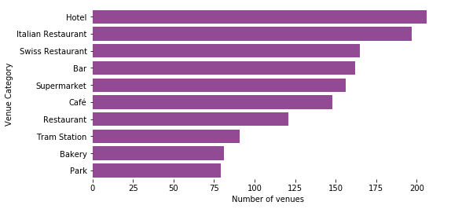

```python
f, ax = plt.subplots(figsize=(8,4))
sns.barplot(x='Count', y=dfc.index, data=dfc, color='#9F3EA0', ax=ax)
sns.despine(left=True, bottom=True)
ax.set(xlabel="Number of venues")
plt.savefig('Outputs/ch_venues.svg')
```

```python
ctgrs = {}
ch_venues2 = ch_venues.copy()
ch_venues2['Neighborhood'] = ch_venues2['Neighborhood'].str[6:]
for city in ch_big10_cities:
    temp = ch_venues2[ch_venues2['Neighborhood'] == city].groupby('Venue Category')['Neighborhood'].count().to_frame('Count')
    tmp = temp.sort_values(by='Count', ascending=False).head(10).index.values + " (" + [str(i) for i in list(temp.sort_values(by='Count', ascending=False).head(10)['Count'])] + ")"
    if len(tmp) < 10:
        n = 10 - len(tmp)
        tmp = np.append(tmp, n*['N/A'])
    ctgrs[city] = tmp

ctgrs = pd.DataFrame.from_dict(ctgrs)
ctgrs
```

|  | Zürich | Genève | Basel | Lausanne | Bern | Winterthur | Luzern | St. Gallen | Lugano | Biel/Bienne |
| --- | --- | --- | --- | --- | --- | --- | --- | --- | --- | --- |
| 0 | Swiss Restaurant (67) | French Restaurant (35) | Hotel (33) | Bar (20) | Swiss Restaurant (22) | Restaurant (9) | Swiss Restaurant (14) | Supermarket (9) | Hotel (30) | Supermarket (8) |
| 1 | Italian Restaurant (60) | Hotel (33) | Italian Restaurant (28) | Italian Restaurant (16) | Hotel (19) | Café (9) | Hotel (13) | Hotel (6) | Italian Restaurant (25) | Hotel (6) |
| 2 | Bar (58) | Italian Restaurant (28) | Tram Station (25) | Supermarket (14) | Supermarket (19) | Italian Restaurant (7) | Café (10) | Bar (6) | Swiss Restaurant (12) | Restaurant (4) |
| 3 | Hotel (53) | Bar (24) | Supermarket (24) | Café (13) | Bar (19) | Bar (6) | Italian Restaurant (9) | Swiss Restaurant (6) | Café (11) | Swiss Restaurant (4) |
| 4 | Café (48) | Park (21) | Café (21) | French Restaurant (12) | Italian Restaurant (17) | Swiss Restaurant (4) | Bar (8) | Bus Stop (5) | Supermarket (10) | Italian Restaurant (4) |
| 5 | Tram Station (46) | Café (17) | Swiss Restaurant (19) | Hotel (12) | Restaurant (17) | Bus Stop (4) | Plaza (8) | Train Station (5) | Restaurant (9) | Bar (3) |
| 6 | Supermarket (44) | Supermarket (17) | Bar (13) | Swiss Restaurant (9) | Café (14) | Supermarket (4) | Supermarket (7) | Restaurant (4) | Pizza Place (8) | Café (3) |
| 7 | Bus Station (43) | Restaurant (15) | Bakery (12) | Burger Joint (8) | Tram Station (13) | Shopping Mall (3) | Asian Restaurant (6) | Music Venue (4) | Soccer Field (5) | Grocery Store (3) |
| 8 | Restaurant (42) | Coffee Shop (14) | Restaurant (11) | Pizza Place (8) | Grocery Store (12) | Grocery Store (3) | Grocery Store (6) | Bakery (4) | Bar (5) | Fast Food Restaurant (3) |
| 9 | Bakery (33) | Pizza Place (12) | Plaza (10) | Park (7) | Plaza (11) | Cocktail Bar (3) | Restaurant (5) | Furniture / Home Store (3) | Electronics Store (5) | Plaza (2) |

### Preparation for k-means clustering

The KMeans algorithm aims to partition n observations into k clusters of equal variance, minimizing a criterion known as the inertia or within-cluster sum-of-squares. This algorithm requires the number of clusters to be specified. It scales well to large number of samples and has been used across a large range of application areas in many different fields.

```python
# one hot encoding
ch_onehot = pd.get_dummies(ch_venues[['Venue Category']], prefix="", prefix_sep="")

# add neighborhood column back to dataframe
ch_onehot['Neighborhood'] = ch_venues['Neighborhood']

# move neighborhood column to the first column
fixed_columns = [ch_onehot.columns[-1]] + list(ch_onehot.columns[:-1])
ch_onehot = ch_onehot[fixed_columns]

ch_grouped = ch_onehot.groupby('Neighborhood').mean().reset_index()
print(ch_grouped.shape)
ch_grouped.head(10)
```

```
(139, 300)
```

|  | Neighborhood | Zoo Exhibit | Accessories Store | African Restaurant | Airport | American Restaurant | Antique Shop | Aquarium | Arcade | Argentinian Restaurant | ... | Vegetarian / Vegan Restaurant | Video Store | Vietnamese Restaurant | Watch Shop | Water Park | Waterfront | Wine Bar | Wine Shop | Yoga Studio | Zoo |
| --- | --- | --- | --- | --- | --- | --- | --- | --- | --- | --- | --- | --- | --- | --- | --- | --- | --- | --- | --- | --- | --- |
| 0 | 1000, Lausanne | 0.0 | 0.00 | 0.0 | 0.0 | 0.0 | 0.0 | 0.000000 | 0.000000 | 0.000000 | ... | 0.000000 | 0.0 | 0.000000 | 0.0 | 0.0 | 0.000000 | 0.00 | 0.0 | 0.0 | 0.0 |
| 1 | 1001, Lausanne | 0.0 | 0.01 | 0.0 | 0.0 | 0.0 | 0.0 | 0.000000 | 0.000000 | 0.000000 | ... | 0.010000 | 0.0 | 0.000000 | 0.0 | 0.0 | 0.000000 | 0.03 | 0.0 | 0.0 | 0.0 |
| 2 | 1002, Lausanne | 0.0 | 0.00 | 0.0 | 0.0 | 0.0 | 0.0 | 0.000000 | 0.000000 | 0.000000 | ... | 0.000000 | 0.0 | 0.000000 | 0.0 | 0.0 | 0.000000 | 0.00 | 0.0 | 0.0 | 0.0 |
| 3 | 1004, Lausanne | 0.0 | 0.00 | 0.0 | 0.0 | 0.0 | 0.0 | 0.000000 | 0.022222 | 0.000000 | ... | 0.000000 | 0.0 | 0.000000 | 0.0 | 0.0 | 0.000000 | 0.00 | 0.0 | 0.0 | 0.0 |
| 4 | 1005, Lausanne | 0.0 | 0.00 | 0.0 | 0.0 | 0.0 | 0.0 | 0.000000 | 0.000000 | 0.000000 | ... | 0.000000 | 0.0 | 0.047619 | 0.0 | 0.0 | 0.000000 | 0.00 | 0.0 | 0.0 | 0.0 |
| 5 | 1006, Lausanne | 0.0 | 0.00 | 0.0 | 0.0 | 0.0 | 0.0 | 0.000000 | 0.000000 | 0.015625 | ... | 0.000000 | 0.0 | 0.000000 | 0.0 | 0.0 | 0.015625 | 0.00 | 0.0 | 0.0 | 0.0 |
| 6 | 1007, Lausanne | 0.0 | 0.00 | 0.0 | 0.0 | 0.0 | 0.0 | 0.000000 | 0.000000 | 0.000000 | ... | 0.022727 | 0.0 | 0.000000 | 0.0 | 0.0 | 0.000000 | 0.00 | 0.0 | 0.0 | 0.0 |
| 7 | 1010, Lausanne | 0.0 | 0.00 | 0.0 | 0.0 | 0.0 | 0.0 | 0.083333 | 0.000000 | 0.000000 | ... | 0.000000 | 0.0 | 0.000000 | 0.0 | 0.0 | 0.000000 | 0.00 | 0.0 | 0.0 | 0.0 |
| 8 | 1011, Lausanne | 0.0 | 0.00 | 0.0 | 0.0 | 0.0 | 0.0 | 0.000000 | 0.000000 | 0.000000 | ... | 0.000000 | 0.0 | 0.000000 | 0.0 | 0.0 | 0.000000 | 0.00 | 0.0 | 0.0 | 0.0 |
| 9 | 1012, Lausanne | 0.0 | 0.00 | 0.0 | 0.0 | 0.0 | 0.0 | 0.000000 | 0.000000 | 0.000000 | ... | 0.000000 | 0.0 | 0.000000 | 0.0 | 0.0 | 0.000000 | 0.00 | 0.0 | 0.0 | 0.0 |

10 rows × 300 columns

```python
def return_most_common_venues(row, num_top_venues):
    row_categories = row.iloc[1:]
    row_categories_sorted = row_categories.sort_values(ascending=False)

    return row_categories_sorted.index.values[0:num_top_venues]
```

```python
num_top_venues = 10

indicators = ['st', 'nd', 'rd']

# create columns according to number of top venues
columns = ['Neighborhood']
for ind in np.arange(num_top_venues):
    try:
        columns.append('{}{} Most Common Venue'.format(ind+1, indicators[ind]))
    except:
        columns.append('{}th Most Common Venue'.format(ind+1))

# create a new dataframe
neighborhoods_venues_sorted = pd.DataFrame(columns=columns)
neighborhoods_venues_sorted['Neighborhood'] = ch_grouped['Neighborhood']

for ind in np.arange(ch_grouped.shape[0]):
    neighborhoods_venues_sorted.iloc[ind, 1:] = return_most_common_venues(ch_grouped.iloc[ind, :], num_top_venues)

neighborhoods_venues_sorted.head(5)
```

|  | Neighborhood | 1st Most Common Venue | 2nd Most Common Venue | 3rd Most Common Venue | 4th Most Common Venue | 5th Most Common Venue | 6th Most Common Venue | 7th Most Common Venue | 8th Most Common Venue | 9th Most Common Venue | 10th Most Common Venue |
| --- | --- | --- | --- | --- | --- | --- | --- | --- | --- | --- | --- |
| 0 | 1000, Lausanne | Swiss Restaurant | French Restaurant | IT Services | Pizza Place | Athletics & Sports | Event Space | Donut Shop | Eastern European Restaurant | Electronics Store | English Restaurant |
| 1 | 1001, Lausanne | Bar | French Restaurant | Burger Joint | Japanese Restaurant | Italian Restaurant | Plaza | Chinese Restaurant | Restaurant | Pizza Place | Wine Bar |
| 2 | 1002, Lausanne | Bar | Italian Restaurant | Thai Restaurant | Park | Sandwich Place | Gastropub | Tea Room | Boutique | Coffee Shop | Pool |
| 3 | 1004, Lausanne | Grocery Store | Supermarket | Bus Stop | Bar | Italian Restaurant | Gas Station | Theater | Sushi Restaurant | Chinese Restaurant | Steakhouse |
| 4 | 1005, Lausanne | Italian Restaurant | Supermarket | Hotel | Park | Coffee Shop | Café | Burger Joint | English Restaurant | Middle Eastern Restaurant | Fast Food Restaurant |

```python
# set number of clusters
kclusters = 10
ch_grouped_clustering = ch_grouped.drop('Neighborhood', axis=1)

# run k-means clustering
kmeans = KMeans(n_clusters=kclusters, random_state=0).fit(ch_grouped_clustering)
```

```python
neighborhoods_venues_sorted['Cluster Labels'] = kmeans.labels_
```

```python
lat, lng = [], []
for city in neighborhoods_venues_sorted['Neighborhood']:
    lat.append(ch_venues[ch_venues['Neighborhood'] == city].reset_index().loc[0, 'Neighborhood Latitude'])
    lng.append(ch_venues[ch_venues['Neighborhood'] == city].reset_index().loc[0, 'Neighborhood Longitude'])
neighborhoods_venues_sorted['Latitude'] = lat
neighborhoods_venues_sorted['Longitude'] = lng
```

```python
lat_lng_coords = None
while(lat_lng_coords is None):
    g = geocoder.google('Switzerland')
    lat_lng_coords = g.latlng

# create map
map_clusters = folium.Map(location=[lat_lng_coords[0], lat_lng_coords[1]], zoom_start=8, tiles='CartoDB positron')

# set color scheme for the clusters
'''
x = np.arange(kclusters)
ys = [i+x+(i*x)**2 for i in range(kclusters)]
colors_array = cm.gist_ncar(np.linspace(0, 1, len(ys)))
rainbow = [colors.rgb2hex(i) for i in colors_array]
'''
manual_c = ['#FFE318','#57C2EA', '#13b79c','#000000', '#faf200','#9F3EA0', '#265dca', '#CF3838','#A1A9AD','#4C8949','#7718FF']

# add markers to the map
markers_colors = []
for lat, lon, poi, cluster in zip(neighborhoods_venues_sorted['Latitude'], neighborhoods_venues_sorted['Longitude'], neighborhoods_venues_sorted['Neighborhood'], neighborhoods_venues_sorted['Cluster Labels']):
    label = folium.Popup(str(poi) + ' Cluster ' + str(cluster), parse_html=True)
    folium.CircleMarker(
        [lat, lon],
        radius=5,
        popup=label,
        color=manual_c[cluster-1],
        fill=True,
        fill_color=manual_c[cluster-1],
        fill_opacity=1).add_to(map_clusters)

map_clusters
```

[interactive chart not shown]

```python
neighborhoods_venues_sorted.loc[neighborhoods_venues_sorted['Cluster Labels'] == 0, neighborhoods_venues_sorted.columns[[0] + list(range(1, neighborhoods_venues_sorted.shape[1]))]]
```

|  | Neighborhood | 1st Most Common Venue | 2nd Most Common Venue | 3rd Most Common Venue | 4th Most Common Venue | 5th Most Common Venue | 6th Most Common Venue | 7th Most Common Venue | 8th Most Common Venue | 9th Most Common Venue | 10th Most Common Venue | Cluster Labels | Latitude | Longitude |
| --- | --- | --- | --- | --- | --- | --- | --- | --- | --- | --- | --- | --- | --- | --- |
| 23 | 1289, Genève | Concert Hall | Hotel | Pub | Korean Restaurant | Bar | Restaurant | Italian Restaurant | Salad Place | Wine Shop | Falafel Restaurant | 0 | 46.2058 | 6.1416 |
| 26 | 2502, Biel/Bienne | Hotel | Watch Shop | Bowling Alley | Light Rail Station | Restaurant | Italian Restaurant | Park | Food | Pizza Place | Farm | 0 | 47.1430 | 7.2468 |
| 29 | 2505, Biel/Bienne | Hotel | Seafood Restaurant | Italian Restaurant | Doner Restaurant | Donut Shop | Eastern European Restaurant | Electronics Store | English Restaurant | Ethiopian Restaurant | Event Space | 0 | 47.1342 | 7.2188 |
| 41 | 3014, Bern | Hotel | Italian Restaurant | Restaurant | Gym / Fitness Center | Shopping Mall | Soccer Stadium | Stadium | Supermarket | Grocery Store | Train Station | 0 | 46.9622 | 7.4584 |
| 45 | 3019, Bern | Restaurant | Hotel | Farm | Ethiopian Restaurant | Dog Run | Doner Restaurant | Donut Shop | Eastern European Restaurant | Electronics Store | English Restaurant | 0 | 46.9310 | 7.3479 |
| 71 | 6876, Lugano | Italian Restaurant | Restaurant | Discount Store | Dog Run | Doner Restaurant | Donut Shop | Eastern European Restaurant | Electronics Store | English Restaurant | Ethiopian Restaurant | 0 | 45.9821 | 8.9936 |
| 76 | 6912, Lugano | Hotel | Swiss Restaurant | Italian Restaurant | Food | Mountain | Lighthouse | Scenic Lookout | Nightclub | Fast Food Restaurant | Cocktail Bar | 0 | 45.9798 | 8.9447 |
| 81 | 6925, Lugano | Hotel | Italian Restaurant | Irish Pub | Restaurant | Bike Rental / Bike Share | Swiss Restaurant | Bakery | BBQ Joint | Grocery Store | Train Station | 0 | 45.9927 | 8.9391 |
| 83 | 6962, Lugano | Hotel | Cable Car | Italian Restaurant | Park | Supermarket | Café | Farm | Falafel Restaurant | Factory | Event Space | 0 | 46.0121 | 8.9692 |
| 87 | 6974, Lugano | Hotel | Restaurant | Trail | Swiss Restaurant | Mountain | Electronics Store | Dog Run | Doner Restaurant | Donut Shop | Eastern European Restaurant | 0 | 46.0097 | 8.9810 |

### Discussion

Using 10 clusters for the analysis, it appears that zip code points can be categorized by looking at the most common venues around. The four main clusters are therefore representing the following common places:

**Cluster 0:** Tourist points, such as *hotels*, cafés and other leisure points, including Italian and seafood restaurants.  
**Cluster 1:** Shopping points, such as *supermarkets*, *shopping malls*, *gas stations*, and some public transport and food points.  
**Cluster 3:** Travelling points, such as *bus*, *tram* and *railway* stations with accompanying fast food places (steakhouses, pizza, BBQ places, etc.) and some restaurants.  
**Cluster 6:** Central area places, such as *bars*, *restaurants*, *café* places and many other spots of leisure activities (boutiques, music venues, art venues, parks, etc.)

Most of the cities show a similar pattern: **cluster 6** in the central areas, while **cluster 3** and **cluster 1** are in the periphery. This is natural, as all the leisure activities are happening in the central areas of the city, while the points of commute and shopping are situated in the periphery. Certain cities show the "touristic" side dominating, by having **cluster 0** within their borders.

The two very similar cities from the French-speaking part of Switzerland: Lausanne and Geneva, have rather similar clustering. The difference is that central Geneva contains a "touristic" cluster, while Lausanne clusters suggest shopping venues are more common. A small city of Biel/Bienne, where both French and German are spoken, has a rather similar clustering. Clusters of the capital, Bern, suggest more venues with leisure activities across town, with traveling points, supermarkets and hotels around. Luzern and Basel, despite the difference in size, have similarly colored clusters. However, Basel has a very specific cluster that includes cultural and animal-loving venues. The biggest city of Switzerland, Zurich, is clustered in a typical way with leisure venues (bars, restaurants, etc.) all across the city center, and commuting and shopping points dominating the periphery. Winterthur and Sankt Gallen each have a particular cluster, that they share with Lugano (electronic stores and hotels as the most common venues, respectively). That makes Lugano, a single city from the Italian-speaking part of the country, the most diverse city in the clustering analysis. In fact, it contains all the clusters, excluding the two specific ones (Lausanne and Basel). Apart from the central leisure venues, the periphery contains clusters with traveling stops and stations. Lugano is the city with most prominent touristic clusters with hotels as the most common venue.

## Getting more data about particular venues

### Example of restaurants

The same zip codes dataframe will be used here, with a difference of searching for a particular venue type: **restaurants**. All the points from all the cities will be queried for restaurants within **1km** radius. The same code could be applied to any other venue type, such as a hotel, bar, etc.

```python
def search_for_venues(query, names, latitudes, longitudes, radius = 1000, LIMIT = 200):

    '''
    The function searches for a pre-defined query and obtains a number of venues within a specified limit.
    It returns a dataframe containing, among other details, a venue ID.

    '''

    venues_list = []
    for name, lat, lng in zip(names, latitudes, longitudes):

        # create the API request URL
        url = 'https://api.foursquare.com/v2/venues/search?client_id={}&client_secret={}&ll={},{}&v={}&query={}&radius={}&limit={}'.format(
            CLIENT_ID,
            CLIENT_SECRET,
            lat,
            lng,
            VERSION,
            query,
            radius,
            LIMIT)

        # make the GET request
        results = requests.get(url).json()['response']['venues']

        # return only relevant information for each nearby venue
        for v in results:

            try:
                cat = v['categories'][0]['name']
            except:
                cat = None

            try:
                ven_id = v['id']
            except:
                ven_id = None

            vlt = v['location']['lat'],
            vln = v['location']['lng'],

            venues_list.append([
            name,
            lat,
            lng,
            v['name'],
            cat,
            ven_id, vlt, vln])

    nearby_venues = pd.DataFrame(venues_list)
    nearby_venues.columns = ['Neighborhood',
                  'Latitude',
                  'Longitude',
                  'Venue',
                  'Venue Category',
                  'Venue id', 'Venue Latitude', 'Venue Longitude']

    return(nearby_venues)
```

```python
ch_restaurants = search_for_venues('restaurant', ch_cities['City'], ch_cities['Latitude'], ch_cities['Longitude'])
print(ch_restaurants.shape)
ch_restaurants.head(5)
```

```
(3158, 8)
```

|  | Neighborhood | Latitude | Longitude | Venue | Venue Category | Venue id | Venue Latitude | Venue Longitude |
| --- | --- | --- | --- | --- | --- | --- | --- | --- |
| 0 | 3000, Bern | 46.9167 | 7.4667 | Tanaka Newstyle Restaurant | Japanese Restaurant | 4bd972032e6f0f47e78b0a08 | (46.915384,) | (7.468045,) |
| 1 | 3000, Bern | 46.9167 | 7.4667 | Restaurant Racket | Snack Place | 4db54e1593a017099de8403c | (46.910218,) | (7.469443,) |
| 2 | 3001, Bern | 46.9470 | 7.4404 | Restaurant Brasserie Anker | Swiss Restaurant | 4b71aa20f964a52097542de3 | (46.94844622489236,) | (7.4474809051323385,) |
| 3 | 3001, Bern | 46.9470 | 7.4404 | Restaurant Zunft zu Webern | Swiss Restaurant | 4cdc60ed5aeda1cd6c4cc211 | (46.94814837565194,) | (7.452999056988744,) |
| 4 | 3001, Bern | 46.9470 | 7.4404 | Restaurant Zähringerhof | Italian Restaurant | 4d7768113915721e479aff82 | (46.953051,) | (7.435806,) |

```python
# As some search queries are very close to each other, certainly there are duplicates
ch_restaurants.drop_duplicates(subset='Venue id', keep="first", inplace=True)
```

```python
splc = lambda x: x[0]
ch_restaurants['Venue Latitude'] = ch_restaurants['Venue Latitude'].apply(splc)
ch_restaurants['Venue Longitude'] = ch_restaurants['Venue Longitude'].apply(splc)
print(ch_restaurants.shape)
ch_restaurants.head(5)
```

```
(1430, 8)
```

|  | Neighborhood | Latitude | Longitude | Venue | Venue Category | Venue id | Venue Latitude | Venue Longitude |
| --- | --- | --- | --- | --- | --- | --- | --- | --- |
| 0 | 3000, Bern | 46.9167 | 7.4667 | Tanaka Newstyle Restaurant | Japanese Restaurant | 4bd972032e6f0f47e78b0a08 | 46.915384 | 7.468045 |
| 1 | 3000, Bern | 46.9167 | 7.4667 | Restaurant Racket | Snack Place | 4db54e1593a017099de8403c | 46.910218 | 7.469443 |
| 2 | 3001, Bern | 46.9470 | 7.4404 | Restaurant Brasserie Anker | Swiss Restaurant | 4b71aa20f964a52097542de3 | 46.948446 | 7.447481 |
| 3 | 3001, Bern | 46.9470 | 7.4404 | Restaurant Zunft zu Webern | Swiss Restaurant | 4cdc60ed5aeda1cd6c4cc211 | 46.948148 | 7.452999 |
| 4 | 3001, Bern | 46.9470 | 7.4404 | Restaurant Zähringerhof | Italian Restaurant | 4d7768113915721e479aff82 | 46.953051 | 7.435806 |

```python
def get_venue_details(v_ids):
    '''
    The function obtains details of a venue with a provided ID.
    It returns a dataframe with new information about venues:
    rating, price tier, number of likes, etc.
    '''

    venue_ratings = []

    for v_id in v_ids:

        url = 'https://api.foursquare.com/v2/venues/{}?client_id={}&client_secret={}&v={}'.format(
            v_id,
            CLIENT_ID,
            CLIENT_SECRET,
            VERSION)

        # make the GET request
        results = requests.get(url).json()['response']

        try:
            rtng = results['venue']['rating']
        except:
            rtng = None

        try:
            prc = results['venue']['price']['tier']
        except:
            prc = None

        try:
            lks = results['venue']['likes']['count']
        except:
            lks = None

        venue_ratings.append(
            [v_id,
            rtng,
            prc,
            lks])

    nearby_venues = pd.DataFrame(venue_ratings)
    #nearby_venues = pd.DataFrame([item for venue_ratings in venue_ratings for item in venue_ratings])
    nearby_venues.columns = ['Venue id',
              'Rating',
              'Tier',
              'Likes']

    return(nearby_venues)
```

```python
b = ch_restaurants.iloc[:50,:]
b.reset_index(inplace=True)
print(b.shape)
b.head(5)
```

```
(50, 9)
```

|  | index | Neighborhood | Latitude | Longitude | Venue | Venue Category | Venue id | Venue Latitude | Venue Longitude |
| --- | --- | --- | --- | --- | --- | --- | --- | --- | --- |
| 0 | 0 | 3000, Bern | 46.9167 | 7.4667 | Tanaka Newstyle Restaurant | Japanese Restaurant | 4bd972032e6f0f47e78b0a08 | 46.915384 | 7.468045 |
| 1 | 1 | 3000, Bern | 46.9167 | 7.4667 | Restaurant Racket | Snack Place | 4db54e1593a017099de8403c | 46.910218 | 7.469443 |
| 2 | 2 | 3001, Bern | 46.9470 | 7.4404 | Restaurant Brasserie Anker | Swiss Restaurant | 4b71aa20f964a52097542de3 | 46.948446 | 7.447481 |
| 3 | 3 | 3001, Bern | 46.9470 | 7.4404 | Restaurant Zunft zu Webern | Swiss Restaurant | 4cdc60ed5aeda1cd6c4cc211 | 46.948148 | 7.452999 |
| 4 | 4 | 3001, Bern | 46.9470 | 7.4404 | Restaurant Zähringerhof | Italian Restaurant | 4d7768113915721e479aff82 | 46.953051 | 7.435806 |

```python
a = get_venue_details(b['Venue id'])
a.reset_index(inplace=True)
a.head(5)
```

|  | index | Venue id | Rating | Tier | Likes |
| --- | --- | --- | --- | --- | --- |
| 0 | 0 | 4bd972032e6f0f47e78b0a08 | 8.1 | 2.0 | 14 |
| 1 | 1 | 4db54e1593a017099de8403c | NaN | 1.0 | 0 |
| 2 | 2 | 4b71aa20f964a52097542de3 | 6.6 | 3.0 | 22 |
| 3 | 3 | 4cdc60ed5aeda1cd6c4cc211 | 8.3 | 3.0 | 26 |
| 4 | 4 | 4d7768113915721e479aff82 | NaN | 2.0 | 2 |

```python
resultdf = b.merge(a, on="Venue id", left_index=True, right_index=True)
resultdf.drop(['index_x', 'index_y'], axis=1, inplace=True)
resultdf.tail(5)
```

|  | Neighborhood | Latitude | Longitude | Venue | Venue Category | Venue id | Venue Latitude | Venue Longitude | Rating | Tier | Likes |
| --- | --- | --- | --- | --- | --- | --- | --- | --- | --- | --- | --- |
| 45 | 3001, Bern | 46.947 | 7.4404 | Restaurant Frohsinn Bern | Swiss Restaurant | 4e2a7af5d164223a69777567 | 46.947438 | 7.449260 | NaN | 3.0 | 1 |
| 46 | 3001, Bern | 46.947 | 7.4404 | China Restaurant DaLun | Chinese Restaurant | 50d36533e4b004f08b18fb3c | 46.948501 | 7.440427 | NaN | 1.0 | 0 |
| 47 | 3001, Bern | 46.947 | 7.4404 | Restaurant Kappadokia | Falafel Restaurant | 4d930c9d62ad5481ec52784b | 46.948483 | 7.449423 | NaN | 1.0 | 0 |
| 48 | 3001, Bern | 46.947 | 7.4404 | Restaurant Union | None | 4f8c9699e4b07377e8b64884 | 46.948916 | 7.449166 | NaN | NaN | 0 |
| 49 | 3001, Bern | 46.947 | 7.4404 | Restaurant Warteck | Italian Restaurant | 4da6e17e0cb66f65870e150d | 46.953809 | 7.427722 | 7.5 | 2.0 | 7 |

```python
from IPython.display import HTML
import base64


def create_download_link( df, title = "Download CSV file", filename = "data1.csv"):
    csv = df.to_csv()
    b64 = base64.b64encode(csv.encode())
    payload = b64.decode()
    html = '<a download="{filename}" href="data:text/csv;base64,{payload}" target="_blank">{title}</a>'
    html = html.format(payload=payload,title=title,filename=filename)
    return HTML(html)

create_download_link(resultdf)
```

```python
flnm = []
for i in range(1,30):
    flnm.append('Data/ch_restaurants/final'+ str(i) + '.csv')
```

```python
# Importing files
df_lst = []
for i in flnm:
    df_lst.append(pd.read_csv(i))
```

```python
ch_restaurants = pd.concat(df_lst)
ch_restaurants.drop(['Unnamed: 0'], axis=1, inplace=True)
print(ch_restaurants.shape)
ch_restaurants.head(5)
```

```
(1430, 11)
```

|  | Neighborhood | Latitude | Longitude | Venue | Venue Category | Venue id | Venue Latitude | Venue Longitude | Rating | Tier | Likes |
| --- | --- | --- | --- | --- | --- | --- | --- | --- | --- | --- | --- |
| 0 | 3000, Bern | 46.9167 | 7.4667 | Tanaka Newstyle Restaurant | Japanese Restaurant | 4bd972032e6f0f47e78b0a08 | 46.915384 | 7.468045 | 8.1 | 2.0 | 14.0 |
| 1 | 3000, Bern | 46.9167 | 7.4667 | Restaurant Racket | Snack Place | 4db54e1593a017099de8403c | 46.910218 | 7.469443 | NaN | 1.0 | 0.0 |
| 2 | 3001, Bern | 46.9470 | 7.4404 | Restaurant Brasserie Anker | Swiss Restaurant | 4b71aa20f964a52097542de3 | 46.948446 | 7.447481 | 6.6 | 3.0 | 22.0 |
| 3 | 3001, Bern | 46.9470 | 7.4404 | Restaurant Zunft zu Webern | Swiss Restaurant | 4cdc60ed5aeda1cd6c4cc211 | 46.948148 | 7.452999 | 8.3 | 3.0 | 26.0 |
| 4 | 3001, Bern | 46.9470 | 7.4404 | Restaurant Zähringerhof | Italian Restaurant | 4d7768113915721e479aff82 | 46.953051 | 7.435806 | NaN | 2.0 | 2.0 |

```python
# Percentage of NaN
(100*ch_restaurants.isnull().sum().to_frame('% of data has NaN')/ch_restaurants.shape[0]).round(1).sort_values(by='% of data has NaN', ascending=False)
```

|  | % of data has NaN |
| --- | --- |
| Rating | 70.6 |
| Tier | 21.0 |
| Venue Category | 13.7 |
| Likes | 0.2 |
| Neighborhood | 0.0 |
| Latitude | 0.0 |
| Longitude | 0.0 |
| Venue | 0.0 |
| Venue id | 0.0 |
| Venue Latitude | 0.0 |
| Venue Longitude | 0.0 |

```python
ch_restaurants['Tier'].value_counts().to_frame('Count of instances')
```

|  | Count of instances |
| --- | --- |
| 2.0 | 665 |
| 3.0 | 297 |
| 1.0 | 157 |
| 4.0 | 10 |

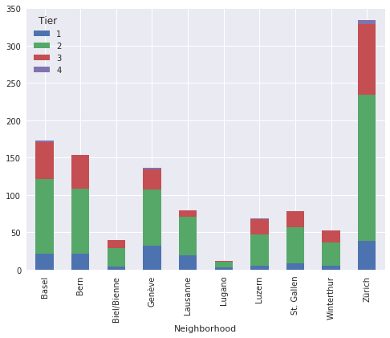

```python
df = ch_restaurants.copy()
def strp(row):
    return row[6:]
df['Neighborhood'] = df['Neighborhood'].apply(strp)
df = df.groupby(['Neighborhood','Tier']).count()['Venue'].to_frame('Number of restaurants')
df.reset_index(inplace=True)
df['Tier'] = df['Tier'].astype(int)
df = df.pivot(index='Neighborhood', columns='Tier', values='Number of restaurants').fillna(0)
df.plot(kind='bar', stacked=True, figsize=(8,6));
plt.savefig('Outputs/rest_tier_box.svg')
```

```python
ch_restaurants['Venue Category'].value_counts().to_frame('Count of instances').head(5)
```

|  | Count of instances |
| --- | --- |
| Restaurant | 307 |
| Swiss Restaurant | 231 |
| Italian Restaurant | 108 |
| French Restaurant | 38 |
| Chinese Restaurant | 33 |

```python
ch_restaurants[['Neighborhood','Venue', 'Likes']].sort_values(by='Likes', ascending=False).head(10)
```

|  | Neighborhood | Venue | Likes |
| --- | --- | --- | --- |
| 30 | 8023, Zürich | Hiltl | 943.0 |
| 8 | 8001, Zürich | Zeughauskeller | 740.0 |
| 28 | 8022, Zürich | Sprüngli | 705.0 |
| 37 | 8000, Zürich | Terrasse | 234.0 |
| 2 | 6006, Luzern | Verkehrshaus der Schweiz | 232.0 |
| 13 | 8005, Zürich | Clouds | 225.0 |
| 37 | 1006, Lausanne | Mövenpick Hotel Lausanne | 168.0 |
| 1 | 8037, Zürich | Restaurant Die Waid | 164.0 |
| 16 | 3001, Bern | Restaurant Lötschberg | 141.0 |
| 49 | 1209, Genève | Luigia | 139.0 |

```python
df = ch_restaurants[['Neighborhood','Venue Latitude', 'Venue Longitude','Venue', 'Likes']].sort_values(by='Likes', ascending=False).head(200)

import geocoder
lat_lng_coords = None
while(lat_lng_coords is None):
    g = geocoder.google('Switzerland')
    lat_lng_coords = g.latlng

map_ch = folium.Map(location=[lat_lng_coords[0], lat_lng_coords[1]], zoom_start=8)

for lat, lng, v, l in zip(df['Venue Latitude'], df['Venue Longitude'], df['Venue'], df['Likes']):
    label = '{}: {} likes'.format(v, int(l))
    label = folium.Popup(label, parse_html=True)
    folium.CircleMarker(
        [lat, lng],
        radius=5,
        popup=label,
        color='#9F3EA0',
        fill=True,
        fill_color='#9F3EA0',
        fill_opacity=1).add_to(map_ch)

map_ch
```

[interactive chart not shown]

```python
ch_restaurants.describe()
```

|  | Latitude | Longitude | Venue Latitude | Venue Longitude | Rating | Tier | Likes |
| --- | --- | --- | --- | --- | --- | --- | --- |
| count | 1430.000000 | 1430.000000 | 1430.000000 | 1430.000000 | 420.000000 | 1129.000000 | 1427.000000 |
| mean | 47.071265 | 7.742271 | 47.071449 | 7.742178 | 7.158571 | 2.141718 | 9.216538 |
| std | 0.473565 | 0.954860 | 0.473830 | 0.955366 | 0.900754 | 0.646407 | 41.555739 |
| min | 45.970100 | 6.102800 | 45.972890 | 6.092606 | 5.000000 | 1.000000 | 0.000000 |
| 25% | 46.939200 | 7.244100 | 46.936853 | 7.246588 | 6.500000 | 2.000000 | 0.000000 |
| 50% | 47.360600 | 7.600000 | 47.359629 | 7.595405 | 7.200000 | 2.000000 | 1.000000 |
| 75% | 47.411900 | 8.538100 | 47.415586 | 8.535332 | 7.800000 | 3.000000 | 6.000000 |
| max | 47.576100 | 9.414100 | 47.581363 | 9.412833 | 9.200000 | 4.000000 | 943.000000 |

```python
ch_restaurants_subset = ch_restaurants[ch_restaurants['Rating'].notnull()].copy()
ch_restaurants_subset.shape
```

```
(420, 11)
```

```python
rest_num = {}
for city in ch_big10_cities:
    temp = ch_restaurants_subset[ch_restaurants_subset['Neighborhood'].str.contains(city)].shape[0]
    temp2 = ch_restaurants_subset[ch_restaurants_subset['Neighborhood'].str.contains(city)].agg('mean')['Rating']
    rest_num[city] = [temp, temp2]

df = pd.DataFrame(rest_num, index=['Number of restaurants with rating', 'Mean rating'])
df = df.transpose().sort_values(by='Number of restaurants with rating', ascending=False)
df['Number of restaurants with rating'] = df['Number of restaurants with rating'].astype(int)
df['Mean rating'] = df['Mean rating'].round(2)
df
```

|  | Number of restaurants with rating | Mean rating |
| --- | --- | --- |
| Zürich | 157 | 7.31 |
| Basel | 57 | 7.18 |
| Bern | 52 | 6.94 |
| Genève | 46 | 7.06 |
| Luzern | 28 | 7.15 |
| Lausanne | 27 | 7.01 |
| St. Gallen | 21 | 7.11 |
| Winterthur | 16 | 7.12 |
| Biel/Bienne | 12 | 7.02 |
| Lugano | 4 | 6.52 |

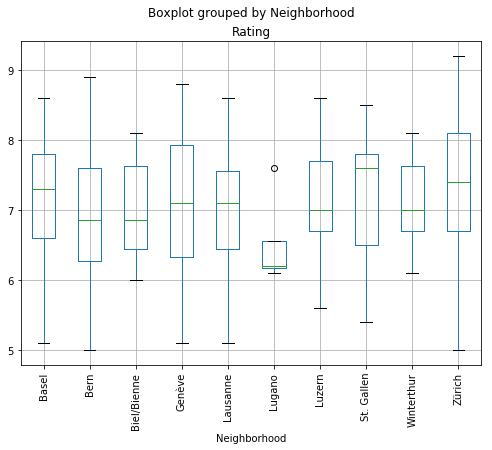

```python
df = ch_restaurants_subset.copy()
def strp(row):
    return row[6:]
df['Neighborhood'] = df['Neighborhood'].apply(strp)
df.set_index(['Neighborhood'], inplace=True)
df = df['Rating'].to_frame()
df.boxplot(column='Rating',by='Neighborhood', figsize=(8,6), rot=90);
```

# Trying to predict the rating

Filling out the few missing values for Tier, based on the most frequent value.

```python
ch_restaurants_subset['Tier'].fillna(2, inplace=True)
ch_restaurants_subset.isnull().sum().to_frame('% of data has NaN').sort_values(by='% of data has NaN', ascending=False)
```

|  | % of data has NaN |
| --- | --- |
| Neighborhood | 0 |
| Latitude | 0 |
| Longitude | 0 |
| Venue | 0 |
| Venue Category | 0 |
| Venue id | 0 |
| Venue Latitude | 0 |
| Venue Longitude | 0 |
| Rating | 0 |
| Tier | 0 |
| Likes | 0 |

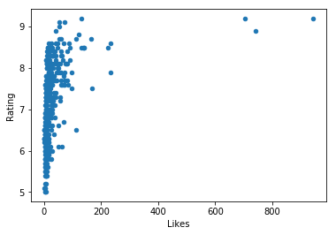

```python
ch_model = ch_restaurants_subset.reset_index()[['Rating', 'Tier', 'Likes']]
ch_model.plot(kind='scatter', x='Likes', y='Rating');
```

```python
x_data = ch_model['Likes']
y_data = ch_model['Rating']
```

```python
from sklearn.model_selection import train_test_split


x_train, x_test, y_train, y_test = train_test_split(x_data, y_data, test_size=0.15, random_state=1)


print("number of test samples :", x_test.shape[0])
print("number of training samples:",x_train.shape[0])
```

```
number of test samples : 63
number of training samples: 357
```

```python
x_test = x_test[1:]
y_test = y_test[1:]
```

```
0.1402587705437135
```

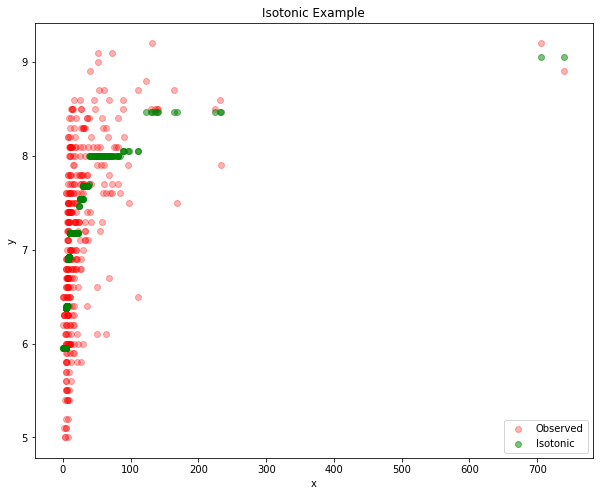

```python
from sklearn.isotonic import IsotonicRegression

ir = IsotonicRegression(y_min=0., increasing='auto')
ir.fit(x_train, y_train)
y_ir = ir.predict(x_train)

plt.figure(figsize=(10, 8))
plt.title('Isotonic Example')
plt.xlabel('x')
plt.ylabel('y')
plt.scatter(x_train, y_train, alpha=0.3, color='red')
plt.scatter(x_train, y_ir, alpha=0.5, color='green')
plt.legend(('Observed', 'Isotonic'))

ir.score(x_test,y_test)
```

```python
from scipy.optimize import curve_fit

x = x_train.values
y = y_train.values

def test_func(x, a, b, c):
    return -0.5*(((1-c)/np.pi)*np.arctan(a*(x-b))) + c/1.3

init_vals = [1, 8, 8.9]
params, covar = curve_fit(test_func, x, y, method='dogbox', p0=init_vals, bounds=([0., 0.,7.],[1., 15.,10.]))
print(params)
```

```
[0.11336578 4.02425551 8.18411096]
```

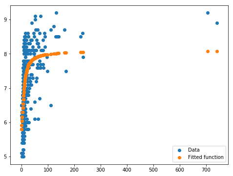

```python
plt.figure(figsize=(8, 6))
plt.scatter(x, y, label='Data')
plt.scatter(x, test_func(x, params[0], params[1], params[2]), label='Fitted function')
plt.legend(loc='best')
plt.show()
```

```
0.2413835423806151
```

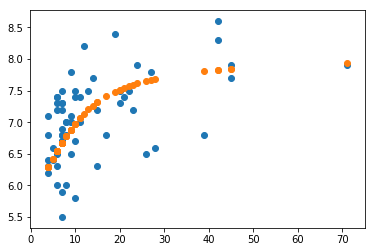

```python
y_true = y_test.values
y_hat = test_func(x_test.values, params[0], params[1], params[2])
plt.scatter(x_test.values, y_true)
plt.scatter(x_test.values, y_hat)
(1 - ((y_true - y_hat) ** 2).sum()/((y_true - y_true.mean()) ** 2).sum())
```

```python
from sklearn.preprocessing import StandardScaler
scaled_features = ch_model['Likes']
scaler = StandardScaler().fit(scaled_features[:, np.newaxis])
scaled_features = scaler.transform(scaled_features[:, np.newaxis])

x_train, x_test, y_train, y_test = train_test_split(scaled_features, y_data, test_size=0.15, random_state=1)

from sklearn.neighbors import KNeighborsRegressor


for i in range(1,11):
    knn = KNeighborsRegressor(n_neighbors=i)
    knn.fit(x_train, y_train)
    predictions = knn.predict(x_test)
    print('i: {}, score: {:+.1f}'.format(i,100*knn.score(x_test, y_test)))
```

```
i: 1, score: -89.5
i: 2, score: -4.2
i: 3, score: +17.5
i: 4, score: +8.4
i: 5, score: +9.3
i: 6, score: +17.7
i: 7, score: +21.9
i: 8, score: +24.5
i: 9, score: +28.3
i: 10, score: +32.5
```

It turns out that the rating cannot be successfully predicted only by the number of likes. More data is surely necessary, but impossible to obtain using a free membership plan.